# COVID19 Analysis

2024-08-06

# Data Cleaning

Giving a brief overview of the data, the columns for global cases are pretty well organized already, we would only need to clean column names, format object types and merge datasets before we can conduct any analysis on the data itself.

```r
global_cases_temp <- global_cases_base %>%
  pivot_longer(cols = -c(`Province/State`, `Country/Region`, Lat, Long),
               names_to = "date",
               values_to = "cases") %>%
  select(-c(Lat, Long))
global_deaths_temp <- global_deaths_base %>%
  pivot_longer(cols = -c(`Province/State`, `Country/Region`, Lat, Long),
               names_to = "date",
               values_to = "deaths") %>%
  select(-c(Lat, Long))
global_data_temp <- global_cases_temp %>%
  full_join(global_deaths_temp) %>%
  rename(Country_Region = `Country/Region`, Province_state = `Province/State`) %>%
  mutate(date = mdy(date))
```

Additionally the data was separated by State or Province, in this analysis we would like to look at countries as a whole rather than by region thus all the countries data were merged into one

```r
global_data_temp <- global_data_temp %>%
  group_by(Country_Region, date) %>%
  summarise(cases=sum(cases), deaths=sum(deaths))
```

Importing data from https://data.worldbank.org/indicator/SP.POP.TOTL?most_recent_value_desc=true on world populations by country as of 2023, this would allow for doing analysis based on population rather than pure numbers

```r
download.file("https://api.worldbank.org/v2/en/indicator/SP.POP.TOTL?downloadformat=csv&_gl=1*1phtnw9*_gcl_au*MTQ5MTI5NTg3Mi4xNzIzNDc0NDU5", dest="dataset.zip", mode="wb")
unzip("dataset.zip", exdir = "./")
pop <- read_csv(".//API_SP.POP.TOTL_DS2_en_csv_v2_3142124.csv", skip=3)
```

```
## ──────────────────────────────────────────────────────── Delimiter: "," chr
## (4): Country Name, Country Code, Indicator Name, Indicator Code dbl (64): 1960,
## 1961, 1962, 1963, 1964, 1965, 1966, 1967, 1968, 1969, 1970, ... lgl (1): ...69
```

```r
pop <- pop %>%
  select(c(`Country Name`, `2023`)) %>%
  rename(Country_Region = `Country Name`, Population = `2023`)
global_data <- merge(global_data_temp, pop, by = "Country_Region", all.x = TRUE)
```

The COVID dataset includes more countries that the population dataset has, in order to perform an analysis we would need to drop the countries which have NA values under population, some NA values occur due to naming differences in the datasets others are because they were missing. We did our best to rename some country names in order to make the data as complete as possible.

```r
temp <- global_data %>%
  group_by(Country_Region) %>%
  summarise(pop = sum(Population)/n())
rows_with_na <- temp[apply(temp, 1, function(x) any(is.na(x))),]
rows_with_na
```

```
## # A tibble: 31 × 2
##    Country_Region        pop
##    <chr>               <dbl>
##  1 Antarctica             NA
##  2 Bahamas                NA
##  3 Brunei                 NA
##  4 Burma                  NA
##  5 Congo (Brazzaville)    NA
##  6 Congo (Kinshasa)       NA
##  7 Diamond Princess       NA
##  8 Egypt                  NA
##  9 Gambia                 NA
## 10 Holy See               NA
## # ℹ 21 more rows
```

It can be seen that 31 points have an NA value for population. Most NA values have been fixed with the following cell

```r
pop$Country_Region[pop$Country_Region == "Bahamas, The"] <- "Bahamas"
pop$Country_Region[pop$Country_Region == "Brunei Darussalam"] <- "Brunei"
pop$Country_Region[pop$Country_Region == "Egypt, Arab Rep."] <- "Egypt"
pop$Country_Region[pop$Country_Region == "Gambia, The"] <- "Gambia"
pop$Country_Region[pop$Country_Region == "Iran, Islamic Rep."] <- "Iran"
pop$Country_Region[pop$Country_Region == "Korea, Dem. People's Rep."] <- "Korea, North"
pop$Country_Region[pop$Country_Region == "Korea, Rep."] <- "Korea, South"
pop$Country_Region[pop$Country_Region == "Kyrgyz Republic"] <- "Kyrgyzstan"
pop$Country_Region[pop$Country_Region == "Lao PDR"] <- "Laos"
pop$Country_Region[pop$Country_Region == "Micronesia, Fed. Sts."] <- "Micronesia"
pop$Country_Region[pop$Country_Region == "Russian Federation"] <- "Russia"
pop$Country_Region[pop$Country_Region == "St. Kitts and Nevis"] <- "Saint Kitts and Nevis"
pop$Country_Region[pop$Country_Region == "St. Lucia"] <- "Saint Lucia"
pop$Country_Region[pop$Country_Region == "St. Vincent and the Grenadines"] <- "Saint Vincent and the Grenadines"
pop$Country_Region[pop$Country_Region == "Slovak Republic"] <- "Slovakia"
pop$Country_Region[pop$Country_Region == "Syrian Arab Republic"] <- "Syria"
pop$Country_Region[pop$Country_Region == "Turkiye"] <- "Turkey"
pop$Country_Region[pop$Country_Region == "United States"] <- "US"
pop$Country_Region[pop$Country_Region == "Venezuela, RB"] <- "Venezuela"
pop$Country_Region[pop$Country_Region == "Viet Nam"] <- "Vietnam"
pop$Country_Region[pop$Country_Region == "Yemen, Rep."] <- "Yemen"
global_data <- merge(global_data_temp, pop, by = "Country_Region", all.x = TRUE)
```

Taking 1 more look at the rows with NA values we have the following

```r
temp <- global_data %>%
  group_by(Country_Region) %>%
  summarise(pop = sum(Population)/n())
rows_with_na <- temp[apply(temp, 1, function(x) any(is.na(x))),]
rows_with_na
```

```
## # A tibble: 10 × 2
##    Country_Region         pop
##    <chr>                <dbl>
##  1 Antarctica              NA
##  2 Burma                   NA
##  3 Congo (Brazzaville)     NA
##  4 Congo (Kinshasa)        NA
##  5 Diamond Princess        NA
##  6 Holy See                NA
##  7 MS Zaandam              NA
##  8 Summer Olympics 2020    NA
##  9 Taiwan*                 NA
## 10 Winter Olympics 2022    NA
```

Only entries left were for countries were we were not able to find population values for in the population dataset, these will be dropped

```r
global_data <- global_data %>%
  drop_na(Population)
```

# Data Analysis

## Deaths per milion

```r
million <- global_data %>%
  mutate(`per Million` = signif(deaths/Population*1000000, 5)) %>%
  mutate(`Death Rate` = signif(deaths/cases * 100, 3))
```

Since the dataset is until 2023-03-09, we will look at the countries deaths per million values on the most recent date

```r
final <- million[million$date == "2023-03-09",] %>%
  select(-date)
head(final[order(final$`per Million`, decreasing=TRUE),])
```

```
##                Country_Region   cases deaths Population per Million Death Rate
## 154156                   Peru 4487553 219539   34352719      6390.7       4.89
## 29638                Bulgaria 1297523  38228    6430370      5944.9       2.95
## 145012        North Macedonia  346852   9662    1811980      5332.3       2.79
## 83241                 Hungary 2196804  48762    9589872      5084.7       2.22
## 24700  Bosnia and Herzegovina  401729  16280    3210847      5070.3       4.05
## 129012                Moldova  611140  12003    2486891      4826.5       1.96
```

```r
head(final[order(final$`Death Rate`, decreasing=TRUE),])
```

```
##        Country_Region   cases deaths Population per Million Death Rate
## 99698    Korea, North       1      6   26160821     0.22935     600.00
## 216027          Yemen   11945   2159   34449825    62.67100      18.10
## 186160          Sudan   63829   5017   48109006   104.28000       7.86
## 190865          Syria   57467   3164   23227014   136.22000       5.51
## 180445        Somalia   27324   1361   18143378    75.01400       4.98
## 154156           Peru 4487553 219539   34352719  6390.70000       4.89
```

```r
head(final[order(final$`per Million`, decreasing=FALSE),])
```

```
##        Country_Region cases deaths Population per Million Death Rate
## 202262         Tuvalu  2805      0      11396     0.00000     0.0000
## 99698    Korea, North     1      6   26160821     0.22935   600.0000
## 31609         Burundi 53631     38   13238559     2.87040     0.0709
## 38804            Chad  7679    194   18278568    10.61400     2.5300
## 142727          Niger  9508    315   27202843    11.58000     3.3100
## 21271           Benin 27999    163   13712828    11.88700     0.5820
```

```r
head(final[order(final$`Death Rate`, decreasing=FALSE),])
```

```
##        Country_Region   cases deaths Population per Million Death Rate
## 202262         Tuvalu    2805      0      11396      0.0000     0.0000
## 137013          Nauru    5247      1      12780     78.2470     0.0191
## 22815          Bhutan   62627     21     787424     26.6690     0.0335
## 31609         Burundi   53631     38   13238559      2.8704     0.0709
## 175996      Singapore 2235294   1722    5917648    290.9900     0.0770
## 197689          Tonga   16810     13     107773    120.6200     0.0773
```

Looking at the results of sorting by deaths per million and death rate we can conclude that Tuvalu which had no deaths from COVID had the lowest death rate at 0% followed by Nauru and Bhutan at 0.019% and 0.034% respectively. In terms of the worst performing countries for treating COVID, ignoring the outlier of North Korea which is likely due to lack of reporting, it would be Yemen at 18.07% death rate followed by Sudan and Syria at 7.86% and 5.51% respectively. Next looking at the deaths per million, the worst performing country we can see would be Peru at 6390.7 deaths per million followed by Bulgaria, North Macedonia, Hungary, Bosnia and Herzegovina all of which had more than 5000 deaths per million. On the other hand, since Tuvalu had no COVID deaths it has the best record at 0 deaths per million with Burundi, Chad and Niger behind it with 2.87, 10.6 and 11.58 deaths per million each.

### Visuilization of deaths per million for most impacted counteries

One way to visualize the data would be to see how the deaths per million of the most affected countries look on a time series plot, we also opted to throw into the plot the data for the US as well as china.

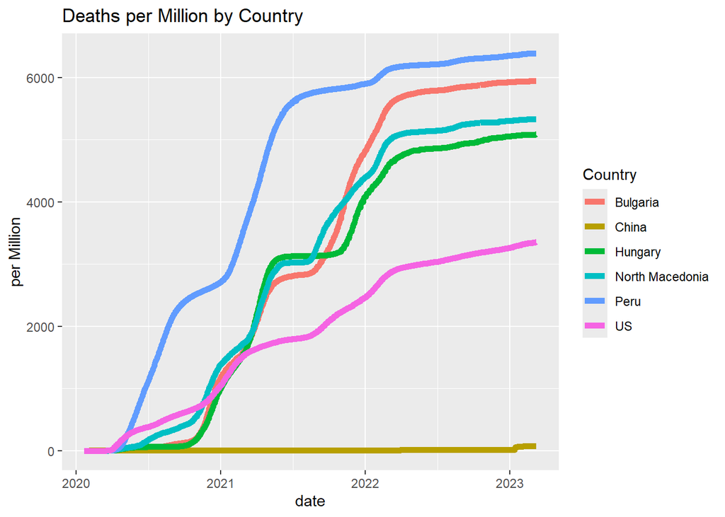

```r
countries <- million[million$Country_Region %in% c("Peru", "Bulgaria", "North Macedonia", "Hungary", "US", "China"),]
ggplot(data=countries, aes(x=date,y=`per Million`)) +
  geom_line(aes(colour=Country_Region), size=2) +
  labs(color = "Country") +
  ggtitle('Deaths per Million by Country')
```

We can see there are periods where there is rapid increases in deaths per million along with some plateaus, these could be the result of lockdowns or vaccines which we will explore below. Additionally although COVID originated from China it would appear that from the analysis, China has a significantly lower deaths per million compared to the other countries, this could likely be a result of under reporting.

### Baises

One of the key factors which would affect how this data is analyzed could be a lack of reporting, it would be entirely possible that there are countries which could not afford to be constantly testing their citizens and thus would result in under reporting in the data which would result in the results skewing.

## The efficacy of lockdown

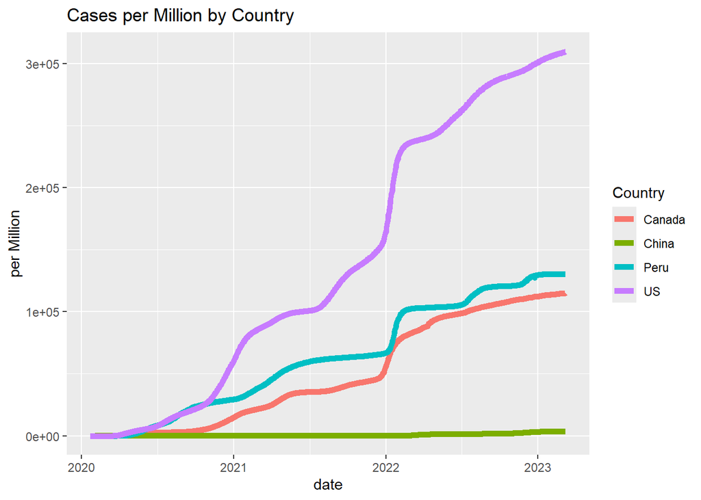

```r
cases <- global_data %>%
  mutate(`per Million` = signif(cases/Population*1000000, 5))
cases <- cases[cases$Country_Region %in% c("Peru", "US", "Canada", "China"),]
ggplot(data=cases, aes(x=date, y=`per Million`)) +
  geom_line(aes(colour=Country_Region), size=2) +
  labs(color = "Country") +
  ggtitle('Cases per Million by Country')
```

From the looks of the data, the data we have from China seems very low compared to the other countries, this is once again likely due to under reporting. We can also see in the data that around the early 2022 mark the number of cases spiked for both US and Canada, this was also around the time lock down restrictions were relaxed, although no conclusions could be made off this it could warrant a look to see if the easing of lockdown restrictions lead the a spike in cases.

## The Efficacy of Vaccines

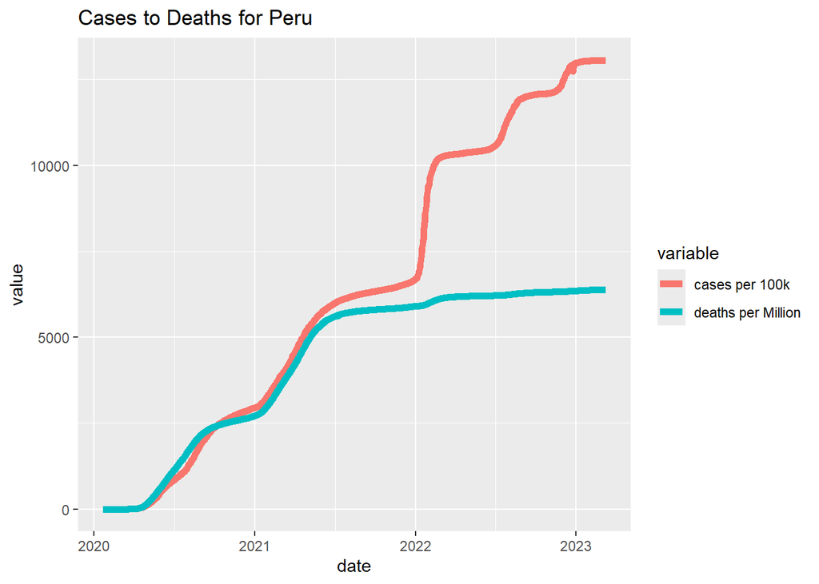

```r
test <- global_data %>%
  mutate(`cases per 100k` = signif(cases/Population*100000, 5)) %>%
  mutate(`deaths per Million` = signif(deaths/Population*1000000, 5))


peru <- test[test$Country_Region == "Peru",] %>%
  select(c(date, `cases per 100k`, `deaths per Million`)) %>%
  gather(key='variable', value = 'value', -c(date))
ggplot(data=peru, aes(x=date, y=value)) +
  geom_line(aes(colour=variable), size=2) +
  ggtitle('Cases to Deaths for Peru')
```

The plot does show that there was a plateau in death rates starting from mid 2021 which was roughly when the vaccine started to roll out, there also was a plateau in the cases around the time the vaccine rolled out only for the spike to happen around early 2022 which was the Omicron surge.

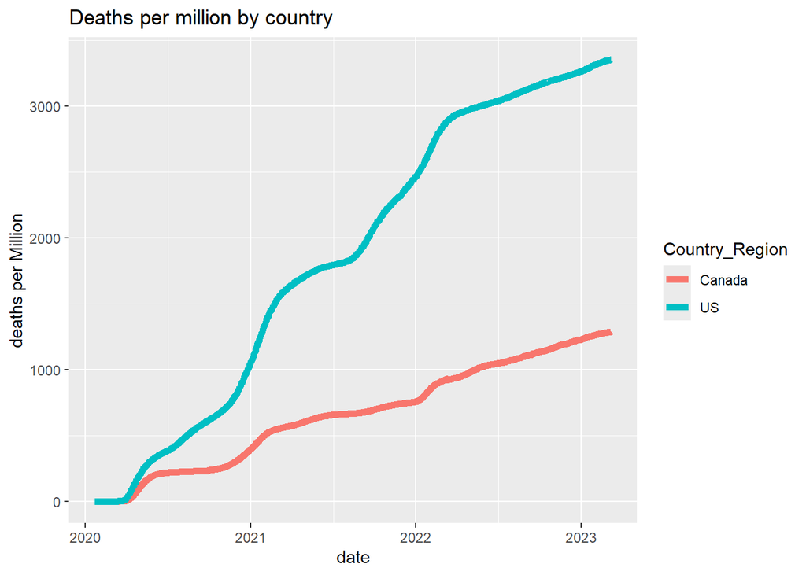

```r
test <- global_data %>%
  mutate(`cases per 100k` = signif(cases/Population*100000, 5)) %>%
  mutate(`deaths per Million` = signif(deaths/Population*1000000, 5))

US <- test[test$Country_Region %in% c("US", "Canada"),]
ggplot(data=US, aes(x=date, y=`deaths per Million`)) +
  geom_line(aes(colour=Country_Region), size=2) +
  ggtitle('Deaths per million by country')
```

## Conclusion

This report analyzed numerical data from various countries to assess how they managed the COVID-19 pandemic. We identified some correlations between the impacts of lockdown measures, vaccination efforts, and the resulting COVID-19 cases and deaths. Although we aimed to base our analysis solely on the available data, there are potential sources of bias that should be considered. For example, the selection of countries was influenced by certain factors—Peru was chosen according to out analysis as having a poor response to the pandemic, while China was included as the origin of the virus. The United States and Canada were selected due to familiarity, which may have influenced our interpretation of trends on specific dates, as prior knowledge of events might have explained changes. Another potential bias arises from the data collection process itself; for instance, China’s data may have been incomplete or under reported, significantly affecting the overall analysis when the full scope of information is not available.